# Clustering and Dimensionality Reduction with Opel Corsa Car Dataset

## PAM

The PAM algorithm is based on the search for k representative objects or medoids among the observations of the data set.

After finding a set of k medoids, clusters are constructed by assigning each observation to the nearest medoid. Next, each selected medoid m and each non-medoid data point are swapped and the objective function is computed. The objective function corresponds to the sum of the dissimilarities of all objects to their nearest medoid.

The SWAP step attempts to improve the quality of the clustering by exchanging selected objects (medoids) and non-selected objects. If the objective function can be reduced by interchanging a selected object with an unselected object, then the swap is carried out. This is continued until the objective function can no longer be decreased. The goal is to find k representative objects which minimize the sum of the dissimilarities of the observations to their closest representative object.

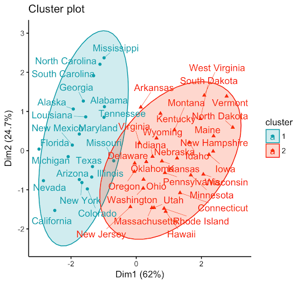

pam

### PAM With 2 and 3 Number of Clusters

Let’s compare PAM with number of clusters `2` and `3`.

```r
pam2 <- eclust(car, k=2 , FUNcluster="pam", hc_metric="euclidean", graph=F)
cp2 <- fviz_cluster(pam2, data=car, elipse.type="convex", geom=c("point")) + ggtitle("PAM with 2 clusters")
sp2 <- fviz_silhouette(pam2)
```

```
##   cluster size ave.sil.width
## 1       1 1566          0.57
## 2       2 1428          0.61
```

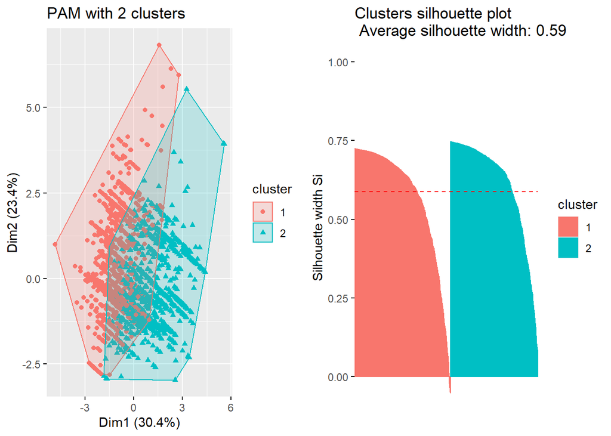

```r
grid.arrange(cp2, sp2, ncol=2)
```

```r
pam3 <- eclust(car, k=3 , FUNcluster="pam", hc_metric="euclidean", graph=F)
cp3 <- fviz_cluster(pam3, data=car, elipse.type="convex", geom=c("point")) + ggtitle("PAM with 3 clusters")
sp3 <- fviz_silhouette(pam3)
```

```
##   cluster size ave.sil.width
## 1       1 1136          0.47
## 2       2  863          0.58
## 3       3  995          0.52
```

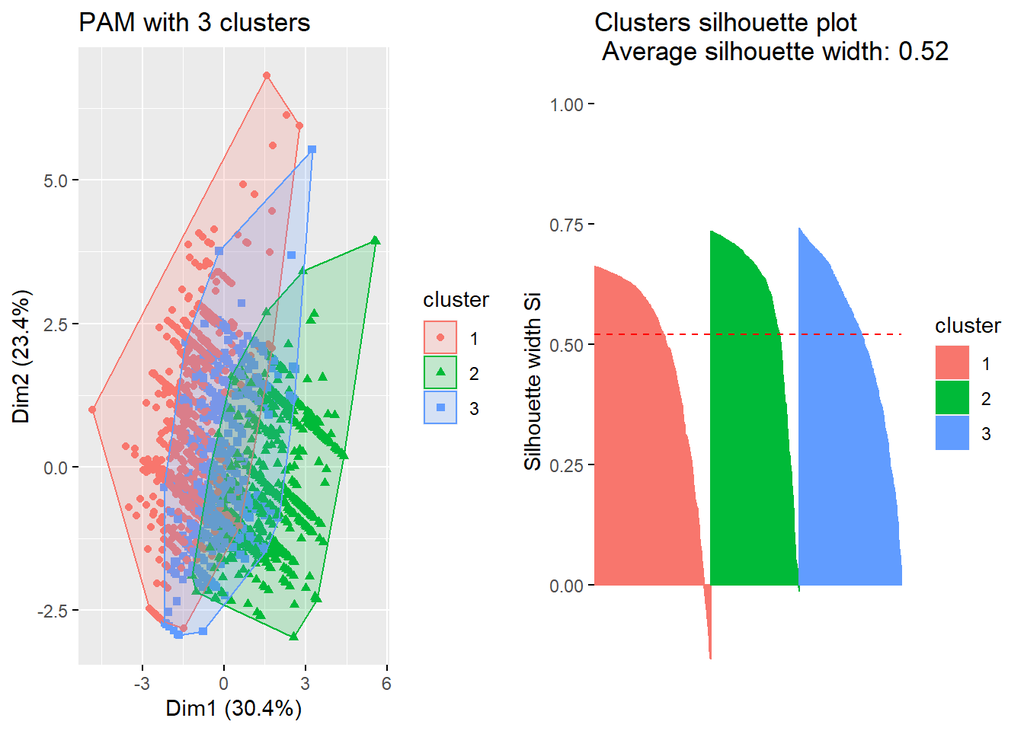

```r
grid.arrange(cp3, sp3, ncol=2)
```

## HIERARCHICAL CLUSTERING

### Hierarchical Clustering

Hierarchical clustering is where you build a cluster tree (a dendrogram) to represent data, where each group (or “node”) links to two or more successor groups. The groups are nested and organized as a tree, which ideally ends up as a meaningful classification scheme. Distances between center points are calculate for each data point by using different type of distance calculation method and creating a distance matrix.

Each node in the cluster tree contains a group of similar data; Nodes group on the graph next to other, similar nodes. Clusters at one level join with clusters in the next level up, using a degree of similarity; The process carries on until all nodes are in the tree, which gives a visual snapshot of the data contained in the whole set. The total number of clusters is not predetermined before you start the tree creation.

**What is Dendongram?**

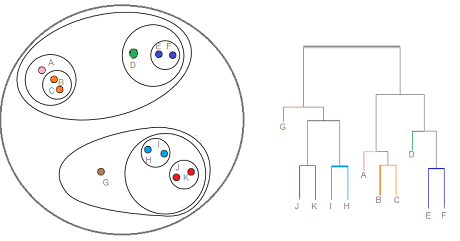

#### HIERARCHICAL CLUSTERING with Euclidean Distance

Let’s compare number of clusters of `2` and `3` with `euclidean distance` in hierarchical clustering.

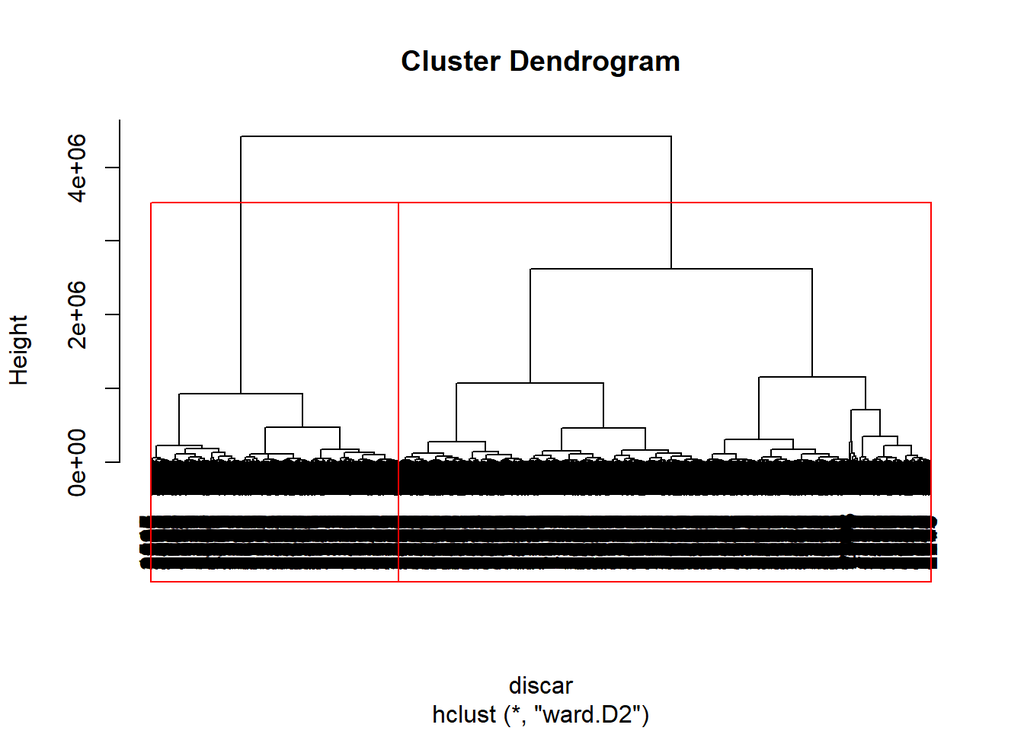

```r
discar<- dist(car, method = "euclidean")
hcar<-hclust(discar, method="ward.D2")
plot(hcar)
groups <- cutree(hcar, k=2)
rect.hclust(hcar, k=2, border="red")
```

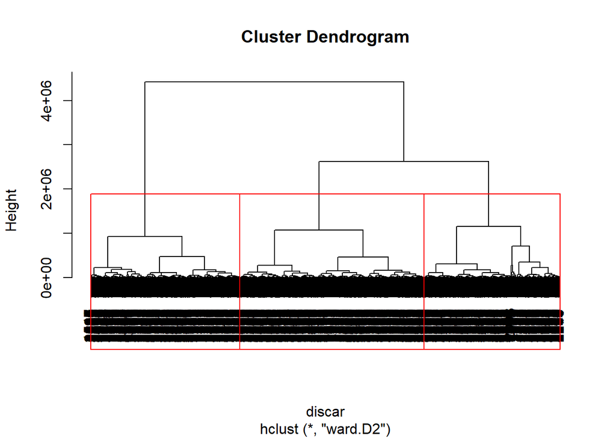

```r
discar<- dist(car, method = "euclidean")
hcar<-hclust(discar, method="ward.D2")
plot(hcar)
groups <- cutree(hcar, k=3)
rect.hclust(hcar, k=3, border="red")
```

#### HIERARCHICAL CLUSTERING with Manhattan Distance

Let’s compare number of clusters of `2` and `3` with `manhattan distance` in hierarchical clustering.

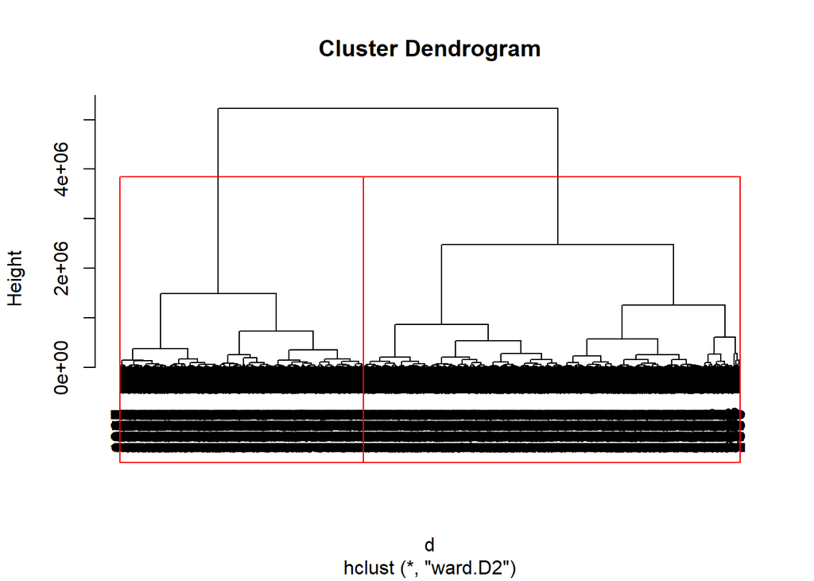

```r
d <- dist(car, method = "manhattan")
H.fit <- hclust(d, method="ward.D2")
plot(H.fit)
groups <- cutree(H.fit, k=2)
rect.hclust(H.fit, k=2, border="red")
```

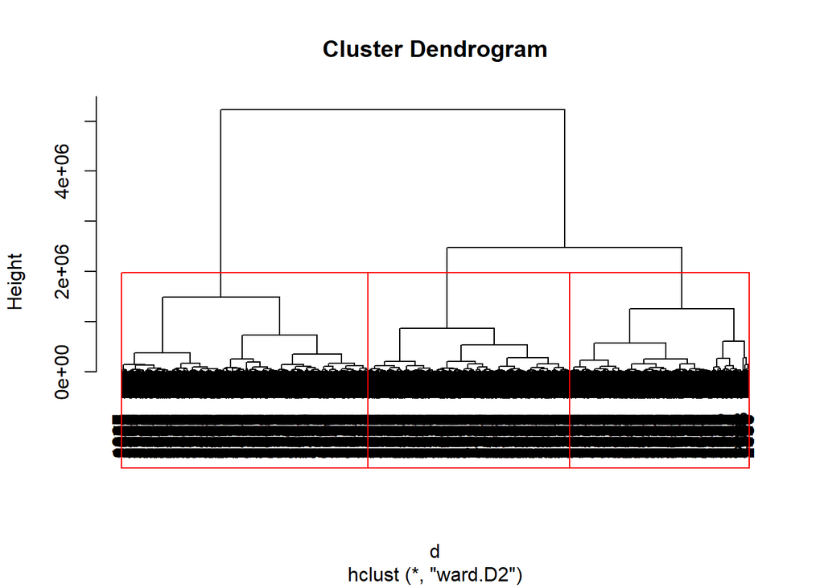

```r
d <- dist(car, method = "manhattan")
H.fit <- hclust(d, method="ward.D2")
plot(H.fit)
groups <- cutree(H.fit, k=3)
rect.hclust(H.fit, k=3, border="red")
```

## BEST CLUSTER

```r
set.seed(123)
final <- kmeans(car, centers = 3, nstart = 25)
print(final$centers)
```

```
##      Price Fuel_Type Gear_Type        Km Engine_Power Engine_Capacity Warranty
## 1 48271.72  1.907098  1.902923  46022.23     85.21294        1295.738 1.328810
## 2 24139.60  1.896000  2.010286 213999.41     76.89486        1312.898 1.113143
## 3 32932.63  1.746770  2.020672 131660.87     77.42291        1265.267 1.117140
```

**FINAL PLOT FOR K-MEANS CLUSTER NUMBER `3`**

```r
f1 <- fviz_cluster(final, car)
f2 <- fviz_silhouette(silhouette(final$cluster,discar))
```

```
##   cluster size ave.sil.width
## 1       1  958          0.59
## 2       2  875          0.52
## 3       3 1161          0.47
```

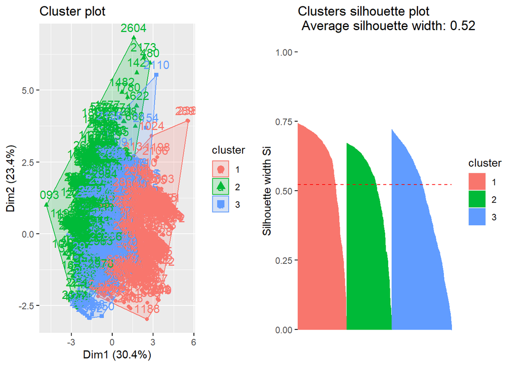

```r
grid.arrange(f1, f2, ncol=2)
```

**PLOT FOR EACH FEATURE WITH CLUSTER**

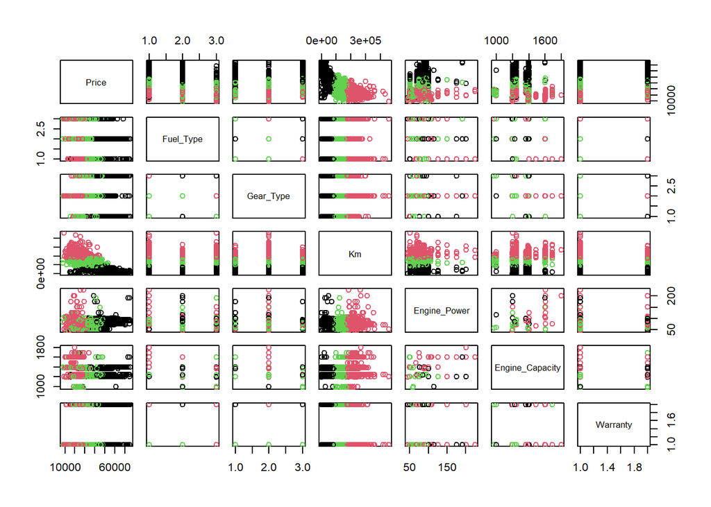

```r
plot(car,col=final$cluster)
```

**PLOT FOR `PRICE` & `KM` WITH CLUSTER**

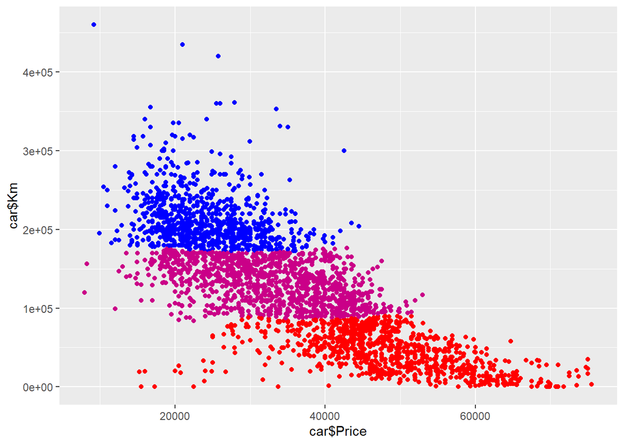

```r
hcar.a<- hclust(discar,method = "average")
hcaralabel<- cutree(hcar.a,3)
hcar.labels<- cutree(hcar,3)

car<- data.frame(car)
ggplot(car,aes(car$Price,car$Km))+geom_point(aes(col=hcar.labels),show.legend = F)+
  scale_color_gradient(low="blue", high="red")##change the colour by the scale
```

# References

- https://bookdown.org/yihui/rmarkdown/
- https://www.imperva.com/blog/clustering-and-dimensionality-reduction-understanding-the-magic-behind-machine-learning/
- https://www.statisticshowto.com/hierarchical-clustering/
- https://rpubs.com/Przemyslaw_Mazurek/579984
- https://rpubs.com/abdul_yunus/Kmeans_Clustering
- https://rpubs.com/Szmariu/distance-metrics-performance
- https://meigarom.github.io/blog/pca.html